# Lab04

John Kaspers

June 2, 2020

#### Warning

**Warning:** If you get an error when running the code, make sure that you have both the ‘alr4’ package and ‘effects’ package installed. You can install them by running the following code in base R (not RStudio or RMarkdown).

> install.packages(‘alr4’)  
> install.packages(‘effects’)  
> install.packages(‘emmeans’)  
> install.package(‘car’)

### Salaries of Professors

We left off Lab 3 working with the `salary` data set. Further information on the data set can be found [here](https://www.rdocumentation.org/packages/alr4/versions/1.0.5/topics/salary).

In Lab 3, we ran a regression model with a factor variable, comparing the salaries for different groups. Now we want to add in a quantitative predictor as well. With a quantitative predictor and a factor variable, we might be interested in determining if the groups have the same slope or if the relationship between X and Y differs by group.

Here, we want to know if the relationship between ‘years in current rank’ and ‘salary’ differ between the three ‘ranks’ (asst, assoc, and prof).

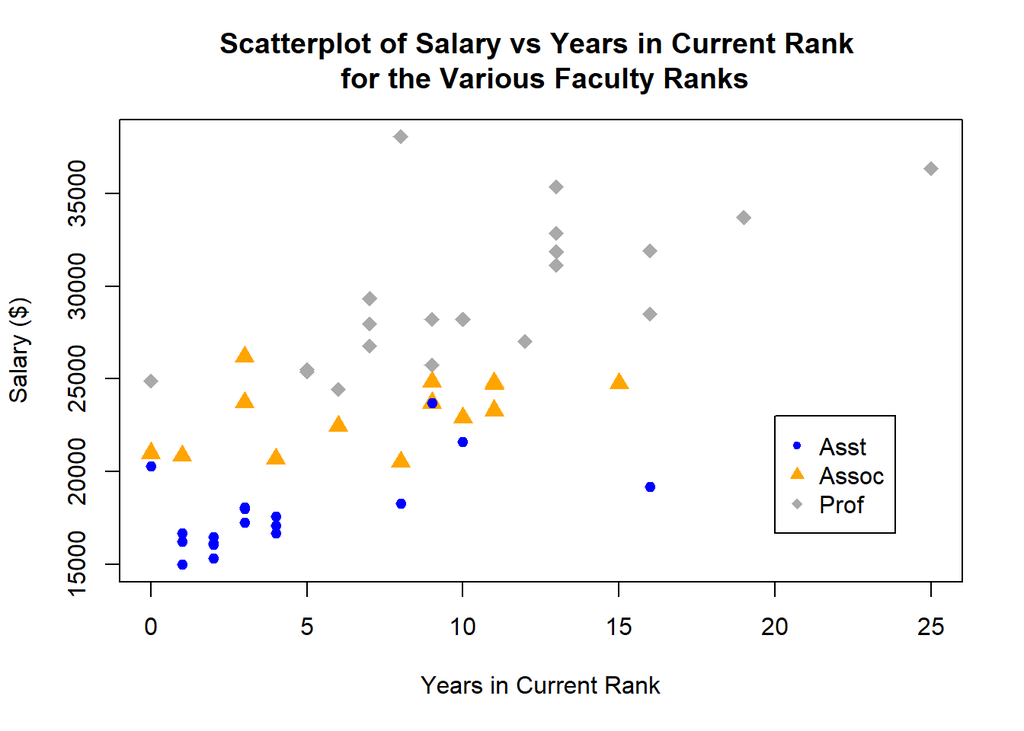

1. Create the model to predict `salary` using `year` and `rank`. In this model, include an interaction term between the two predictors. Run your model through the `summary()` function.

```r
# Write your code here
lm.predict <- lm(salary~year*rank, data = salary)
summary(lm.predict)
```

```
##
## Call:
## lm(formula = salary ~ year * rank, data = salary)
##
## Residuals:
##     Min      1Q  Median      3Q     Max
## -3687.8 -1123.6  -392.1   720.9  9646.6
##
## Coefficients:
##                Estimate Std. Error t value Pr(>|t|)
## (Intercept)     16416.6      816.0  20.118  < 2e-16 ***
## year              324.5      141.9   2.286 0.026887 *
## rankAssoc        5354.2     1492.6   3.587 0.000806 ***
## rankProf         8176.4     1418.1   5.766 6.49e-07 ***
## year:rankAssoc   -129.7      205.8  -0.630 0.531508
## year:rankProf     151.2      171.7   0.880 0.383307
## ---
## Signif. codes:  0 '***' 0.001 '**' 0.01 '*' 0.05 '.' 0.1 ' ' 1
##
## Residual standard error: 2386 on 46 degrees of freedom
## Multiple R-squared:  0.8534, Adjusted R-squared:  0.8375
## F-statistic: 53.56 on 5 and 46 DF,  p-value: < 2.2e-16
```

2. Interpret the slope coefficient for the faculty ranking of assistant. While this slope is statistically significant (at a 5% level), is this *pracitcally* significant? (i.e. Is this a big change in salary?) Note: The mean salary is about $24,000 and this is a subjective answer.

For a one year increase in current rank, we would estimate an average increase of $324.5 in salary, controlling for rank. This is practically significant because although this is a fairly small increase, it is still an increase year over year.

3. Use the `emtrends()` function to calculate the estimated slopes for the other ranks.

```r
emtrends(model = lm.predict, specs = "rank", var = "year")
```

```
##  rank  year.trend    SE df lower.CL upper.CL
##  Asst         325 141.9 46     38.8      610
##  Assoc        195 149.0 46   -105.1      495
##  Prof         476  96.7 46    281.0      670
##
## Confidence level used: 0.95
```

4. Now, use the `pairs()` function to test for statistically significant differences between the slopes for the various ranks.

```r
pairs(emtrends(model = lm.predict, specs = "rank", var = "year"), adjust = "none")
```

```
##  contrast     estimate  SE df t.ratio p.value
##  Asst - Assoc      130 206 46  0.630  0.5315
##  Asst - Prof      -151 172 46 -0.880  0.3833
##  Assoc - Prof     -281 178 46 -1.581  0.1206
```

5. Comment on the statistical significance (using a 5% significance level) of the two interaction terms in your model.

Neither of the interaction terms are statistically significant at the 5% level. This is displayed through the pairs tests run in part 4. While the slopes are not exactly the same for the three ranks, the differences between the slopes are not statistically significant.

6. Visualize the model you created. Pass your model into the following code. Note: Do not worry about changing the default labels for this plot.

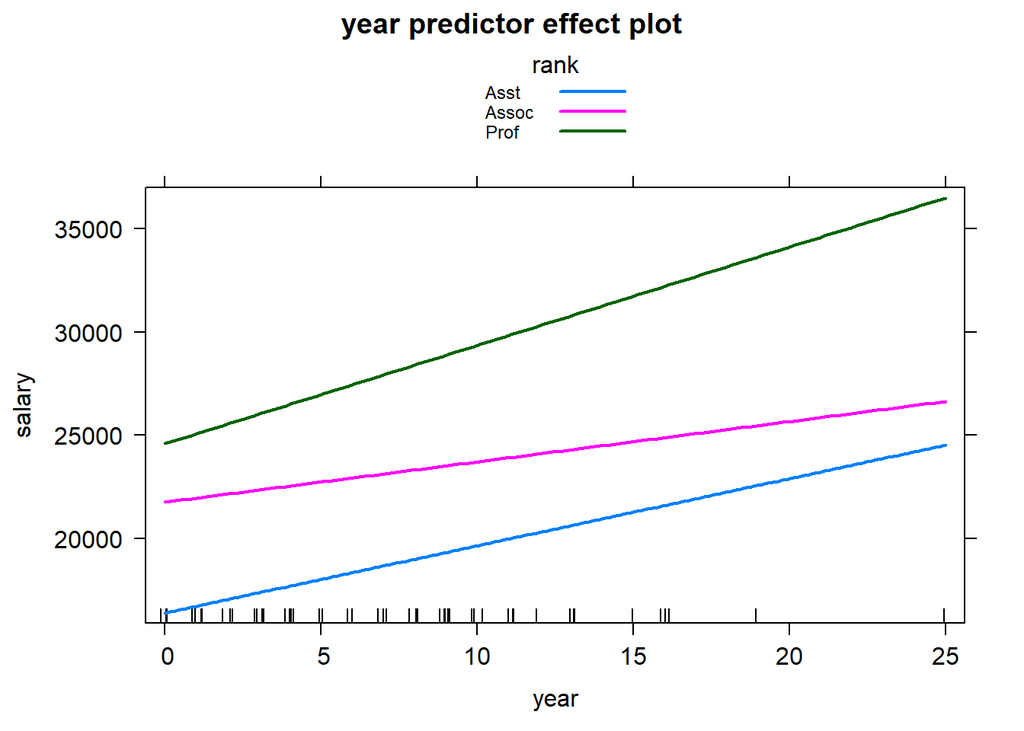

```r
# Uncomment the following line of code and change 'lm.model' to the name of your model
plot(predictorEffect("year", lm.predict), multiline = TRUE)
```

7. Now create the model to predict `salary` using `year` and `rank`, but **do not** include an interaction term between the two predictors. Run your model through the `summary()` function.

```r
# Write your code here
################################ Must go back and find
lm.main <- lm(salary ~ year + rank, data = salary)
summary(lm.main)
```

```
##
## Call:
## lm(formula = salary ~ year + rank, data = salary)
##
## Residuals:
##     Min      1Q  Median      3Q     Max
## -3462.0 -1302.8  -299.2   783.5  9381.6
##
## Coefficients:
##             Estimate Std. Error t value Pr(>|t|)
## (Intercept) 16203.27     638.68  25.370  < 2e-16 ***
## year          375.70      70.92   5.298 2.90e-06 ***
## rankAssoc    4262.28     882.89   4.828 1.45e-05 ***
## rankProf     9454.52     905.83  10.437 6.12e-14 ***
## ---
## Signif. codes:  0 '***' 0.001 '**' 0.01 '*' 0.05 '.' 0.1 ' ' 1
##
## Residual standard error: 2402 on 48 degrees of freedom
## Multiple R-squared:  0.8449, Adjusted R-squared:  0.8352
## F-statistic: 87.15 on 3 and 48 DF,  p-value: < 2.2e-16
```

8. Comment on the statistical significance (using a 5% significance level) of the terms in your model.

All of the main terms are statistically significant at the 5% level.

9. Visualize the model you created. This time we’ll add the individual regression lines to the original scatterplot using the `abline()` function. Modify the code at the bottom of the block by substituting in the intercept (a) and slope (b) for each rank

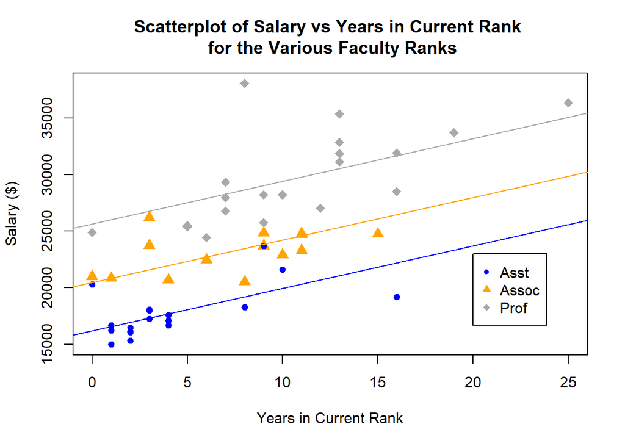

10. Should we include the interaction term in the model or not? Briefly explain why or why not.

No, because they are not statistically significant and including interaction terms complicates our model.

### Ausralian Institute of Sport

Now we’ll use the `ais` data set. Further information on the data set can be found [here](https://www.rdocumentation.org/packages/alr4/versions/1.0.5/topics/ais).

1. Create the model to predict body fat (`Bfat`) using weight (`Wt`), lean body mass (`LBM`), Hematocrit (`Hc`), and Hemoglobin (`Hg`). Do not include any interaction terms. Run your model through the `summary()` function.

```r
# Write your code here
lm.ais1 <- lm(Bfat ~ Wt + LBM + Hc + Hg, data = ais)
summary(lm.ais1)
```

```
##
## Call:
## lm(formula = Bfat ~ Wt + LBM + Hc + Hg, data = ais)
##
## Residuals:
##     Min      1Q  Median      3Q     Max
## -3.7356 -0.3910  0.0677  0.5016  2.3428
##
## Coefficients:
##             Estimate Std. Error t value Pr(>|t|)
## (Intercept) 14.73054    0.83399  17.663   <2e-16 ***
## Wt           1.10565    0.01283  86.183   <2e-16 ***
## LBM         -1.25506    0.01537 -81.680   <2e-16 ***
## Hc           0.03852    0.05287   0.729   0.4671
## Hg          -0.30174    0.14515  -2.079   0.0389 *
## ---
## Signif. codes:  0 '***' 0.001 '**' 0.01 '*' 0.05 '.' 0.1 ' ' 1
##
## Residual standard error: 0.8455 on 197 degrees of freedom
## Multiple R-squared:  0.9817, Adjusted R-squared:  0.9813
## F-statistic:  2644 on 4 and 197 DF,  p-value: < 2.2e-16
```

2. Which variables are statistically significant at the 5% level?

Wt, LBM, and Hg are statistically significant at the 5% level. Hc is not.

3. What perecnt of the variation in body fat is explained by the linear relationship with the four predictors?

98.17%.

4. Use the `vif()` function to see if collinearity exists between any of the predictors.

```r
vif(lm.ais1)
```

```
##        Wt       LBM        Hc        Hg
##  8.974451 11.340994 10.544565 10.997328
```

5. Do any of the variables have a variance inflation factor over 10? If so, which ones?

Yes, LB, Hc and Hg. Wt has a VIF that is quite large too.

6. Create a new model to predict body fat (`Bfat`), but exclude the variable that had the highest VIF in part 4. Use the `vif()` function to see if collinearity exists between any of the predictors.

```r
lm.ais2 <- lm(Bfat ~ Wt + Hc + Hg, data = ais)
vif(lm.ais2)
```

```
##        Wt        Hc        Hg
##  1.262828 10.421401 10.786022
```

7. Do any of the variables have a variance inflation factor over 10? If so, which ones?

Hc and Hg have VIFs over 10. Removing LBM reduced the VIF of Wt. This is because these variables are likely correlated with one another.

8. Create a new model to predict body fat (`Bfat`), but exclude the variable that had the highest VIF in part 6. Use the `vif()` function to see if collinearity exists between any of the predictors.

```r
lm.ais3 <- lm(Bfat ~ Wt + Hc, data = ais)
#summary(lm.ais3)
vif(lm.ais3)
```

```
##     Wt     Hc
## 1.2188 1.2188
```

9. Do any of the variables have a variance inflation factor over 10? If so, which ones?

No!

10. Pass your model from part 8 through the `summary()` function.

```r
summary(lm.ais3)
```

```
##
## Call:
## lm(formula = Bfat ~ Wt + Hc, data = ais)
##
## Residuals:
##      Min       1Q   Median       3Q      Max
## -11.3565  -4.0020  -0.3034   3.2676  15.0274
##
## Coefficients:
##             Estimate Std. Error t value Pr(>|t|)
## (Intercept) 51.59539    4.19416   12.30  < 2e-16 ***
## Wt           0.12213    0.02814    4.34 2.27e-05 ***
## Hc          -1.09647    0.10699  -10.25  < 2e-16 ***
## ---
## Signif. codes:  0 '***' 0.001 '**' 0.01 '*' 0.05 '.' 0.1 ' ' 1
##
## Residual standard error: 5.033 on 199 degrees of freedom
## Multiple R-squared:  0.3454, Adjusted R-squared:  0.3389
## F-statistic: 52.51 on 2 and 199 DF,  p-value: < 2.2e-16
```

11. Which variables are statistically significant at the 5% level?

Both Wt and Hc are statistically significant at the 5% level.

12. What percent of the variation in body fat is explained by the linear relationship with the four predictors?

34.54%

13. So…should we leave all four predictor variables in the model or should we exclude some of them because of collinearity? Breifly describe a scenario in which each answer (leaving them all in and excluding some of them) could be the correct method.

If we are looking to find a model that provides the best overall fit, we would want to keep all of the variables in the model. The predictive power of a model is not reduced because of collinearity. If, on the other hand, we want to determine the individual effects of the predictors, we should think about removing the variables that are highly correlated with eachother because they can give us unreliable estimates.